# Redesim

Analisando dados da Rede Nacional para a Simplificação do Registro e da Legalização de Empresas e Negócios.

Julio Trecenti https://www.linkedin.com/in/jtrecenti/  
2022-06-29

## Introdução

A [Rede Nacional para a Simplificação do Registro e da Legalização de Empresas e Negócios - Redesim](https://www.gov.br/empresas-e-negocios/pt-br/redesim/sobre-a-redesim) foi criada pelo Governo Federal por meio da Lei Nº 11.598, de 3 de dezembro de 2007, e tem por premissas básicas (copiado do site do Governo Federal):

- Abreviar e simplificar os procedimentos para abertura de empresas e
- Diminuir o tempo e o custo para o registro e a legalização das empresas, reduzindo a burocracia ao mínimo necessário.

Para nossos fins jurimétricos, a vantagem da Redesim é que com ela temos uma base de dados bastante interessante.

Em 2021, construímos no Laboratório de Jurimetria um robô de captura dos dados da Redesim. O robô pode ser acessado através do pacote [`{redesim}`](https://github.com/abjur/redesim), que pode ser acessado no GitHub da ABJ.

Para instalar o pacote, basta rodar:

```r
remotes::install_github("abjur/redesim")
```

Para baixar uma base de dados com o robô, basta utilizar a função `redesim_fetch`. No código abaixo, baixamos todos os dados de janeiro a abril 2022, de todas as unidades federativas.

```r
ufs <- sort(unique(abjData::muni$uf_sigla))
da <- redesim::redesim_fetch(
  ano = 2022,
  mes = 1:4,
  uf = ufs
)
```

No final, temos uma base de dados com as seguintes informações:

```r
dplyr::glimpse(da)
```

```
Rows: 217,903
Columns: 42
$ ano_mes_uf                    <chr> "2022-01_AC", "2022-01_AC", "20…
$ serial                        <chr> "AC22011900001", "AC22010400002…
$ dt_inic_viabilidade           <date> 2022-01-18, 2021-12-22, 2021-1…
$ hh_inic_viabilidade           <Period> 9H 23M 42S, 7H 10M 35S, 9H 2…
$ dt_fim_viabilidade_nome       <date> 2022-01-18, 2021-12-22, 2021-1…
$ hh_fim_viabilidade_nome       <Period> 9H 32M 53S, 7H 53M 42S, 9H 4…
$ qtde_hh_viabilidade_nome      <dbl> 0.15, 0.72, 0.34, 14.58, 14.72,…
$ dt_fim_viabilidade_end        <date> 2022-01-18, 2021-12-22, 2021-1…
$ hh_fim_viabilidade_end        <Period> 9H 23M 42S, 9H 6M 24S, 9H 25…
$ qtde_hh_viabilidade_end       <dbl> 0.00, 1.94, 0.00, 17.90, 15.15,…
$ dt_fim_viabilidade_total      <date> 2022-01-18, 2021-12-22, 2021-1…
$ hh_fim_viabilidade_total      <Period> 9H 32M 53S, 9H 6M 24S, 9H 45…
$ qtde_hh_viabilidade_total     <dbl> 0.15, 1.94, 0.34, 17.90, 15.15,…
```

[output cut: 29 more lines]

## Atividades empresariais mais comuns

Meu interesse principal para demonstrar o poder dessa base é no Código Nacional de Atividades Empresariais (CNAE).

Em 2022, as atividades empresariais mais comuns são dadas pela tabela abaixo:

| Seção | Divisão | Grupo | Classe | Subclasse | N | % |
| --- | --- | --- | --- | --- | --- | --- |
| Atividades administrativas e serviços complementares | Serviços de escritório de apoio administrativo e outros serviços prestados principalmente às empresas | Serviços de escritório e apoio administrativo | Serviços combinados de escritório e apoio administrativo | Serviços combinados de escritório e apoio administrativo | 9237 | 0.0423904214260474 |
| Saúde humana e serviços sociais | Atividades de atenção à saúde humana | Atividades de atenção ambulatorial executadas por médicos e odontólogos | Atividades de atenção ambulatorial executadas por médicos e odontólogos | Atividade médica ambulatorial restrita a consultas | 6120 | 0.028085891428755 |
| Comércio reparação de veículos automotores e motocicletas | Comércio varejista | Comércio varejista de produtos novos não especificados anteriormente e de produtos usados | Comércio varejista de artigos do vestuário e acessórios | Comércio varejista de artigos do vestuário e acessórios | 5400 | 0.024781668907725 |
| Alojamento e alimentação | Alimentação | Restaurantes e outros serviços de alimentação e bebidas | Restaurantes e outros estabelecimentos de serviços de alimentação e bebidas | Restaurantes e similares | 4375 | 0.0200777410132031 |
| Atividades profissionais científicas e técnicas | Serviços de arquitetura e engenharia testes e análises técnicas | Serviços de arquitetura e engenharia e atividades técnicas relacionadas | Serviços de engenharia | Serviços de engenharia | 4300 | 0.0197335511672625 |
| Atividades profissionais científicas e técnicas | Atividades de sedes de empresas e de consultoria em gestão empresarial | Atividades de consultoria em gestão empresarial | Atividades de consultoria em gestão empresarial | Atividades de consultoria em gestão empresarial exceto consultoria técnica específica | 3942 | 0.0180906183026392 |
| Saúde humana e serviços sociais | Atividades de atenção à saúde humana | Atividades de atenção ambulatorial executadas por médicos e odontólogos | Atividades de atenção ambulatorial executadas por médicos e odontólogos | Atividade odontológica | 3587 | 0.0164614530318536 |
| Alojamento e alimentação | Alimentação | Restaurantes e outros serviços de alimentação e bebidas | Restaurantes e outros estabelecimentos de serviços de alimentação e bebidas | Lanchonetes casas de chá de sucos e similares | 3511 | 0.0161126739879671 |
| Atividades financeiras de seguros e serviços relacionados | Atividades de serviços financeiros | Atividades de sociedades de participação | Holdings de instituições não financeiras | Holdings de instituições não financeiras | 3492 | 0.0160254792269955 |
| Construção | Construção de edifícios | Construção de edifícios | Construção de edifícios | Construção de edifícios | 3469 | 0.0159199276742404 |

[output cut: 1151 more lines]

## Regiões com maior atividade empresarial

Abaixo, também fiz um mapinha mostrando a atividade empresarial. O tamanho do círculo é proporcional à taxa de empresas por 100 mil habitantes. Considerei apenas municípios com mais de 100 mil habitantes no ano de 2010.

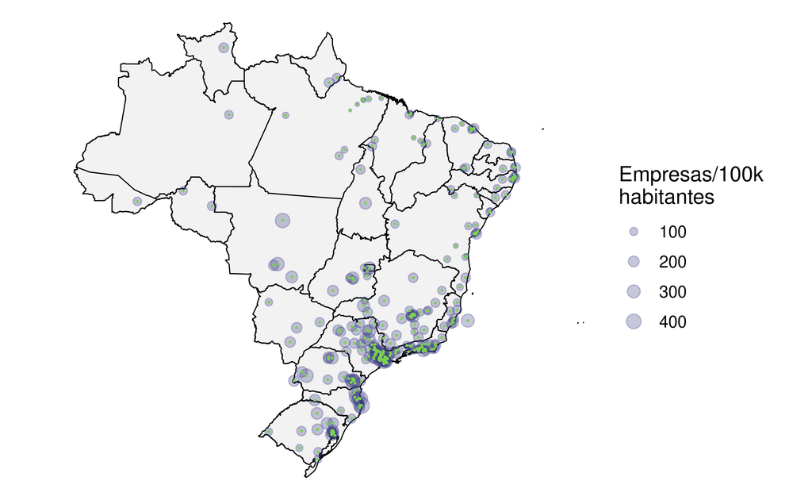

Outro mapa legal que daria para fazer é mostrando as silhuetas dos municípios. Agora a taxa de empresas por 100 mil habitantes está mapeada nas cores. Os municípios marcados são os que apresentam maiores taxas. A atividade apresentação nesses lugares está quente!

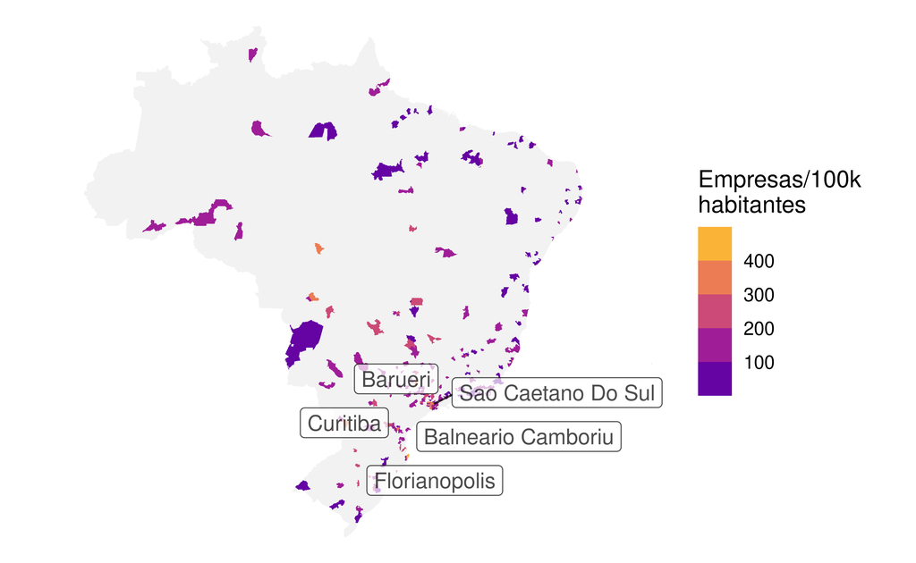

Muito legal né? Que análises você faria com essa base de dados?